# Testy równości średnich

pogRomcy danych

sezon 2 / odcinek 2  
Wszelkie prawa zastrzeżone.  
Wykorzystanie możliwe wyłącznie za zgodą autora.  
Naciśnij `A` by zamienić slajdy na ciągły tekst.  
Naciśnij `T` by wyświetlić spis treści.

# O czym jest ten odcinek

Analizując dane, często trafiamy na sytuację, gdy mamy do porównania dwie grupy pomiarów i jesteśmy ciekawi, czy te grupy różnią się między sobą.

Analizując dane medyczne możemy mieć pacjentów biorących lek A i lek B i chcemy sprawdzić czy skuteczność obu leków jest porównywalna czy też jedne z nich jest częściej lepszy. Analizując uprawę zbóż możemy mieć dwie odmiany i chcemy sprawdzić czy jedna daje wyższe plony niż druga. Takie przykłady można mnożyć.

Zazwyczaj gdy w jednej grupie policzymy średnią okreslonej cechy i w drugiej grupie policzymy średnią tej cechy to któraś z tych średnich jest większa.

Jeżeli porównam średnie temperatury we Wrocławiu i średnie temperatury w Warszawie, to któraś z tych średnich będzie większa. Ale czy ta różnica wynika z losowych fluktuacji temperatury czy też jest odzwierciedleniem pewnej ogólnej prawidłowości, że w jednym z tych miast jest średnio cieplej?

I tutaj pojawia się statystyka. Używając takich narzędzi jak testy dla dwóch prób możemy pomóc sobie w odpowiedzi na pytanie, czy obserwowane różnice są czysto przypadkowe, czy też nie.

# Czy serial Friends jest lepszy niż serial Braking Bed?

W bazie danych o filmach IMDB (Internet Movie Database) znaleźć można dane o serialach a w szczególności średnie oceny użytkowników wystawione kolejnym odcinkom serialu.

Przykładowo, na stronie http://www.imdb.com/title/tt0108778/epdate?ref_=ttep_ql_4 znajdują się oceny serialu *Friends* a na stronie http://www.imdb.com/title/tt0903747/epdate?ref_=ttep_ql_4 oceny serialu *Breaking Bad*.

Dane te zostały pobrane z Internetu i przygotowane tak, że teraz są dostępne w zbiorze danych `serialeIMDB` w pakiecie `PogromcyDanych`, który towarzyszy temu kursowi.

```r
library(PogromcyDanych)
head(serialeIMDB)
```

```
##   id       serial                         nazwa sezon odcinek ocena glosow
## 1  1 Breaking Bad                         Pilot     1       1   8.7   9346
## 2  2 Breaking Bad           Cat's in the Bag...     1       2   8.2   6496
## 3  3 Breaking Bad ...And the Bag's in the River     1       3   8.3   6168
## 4  4 Breaking Bad                    Cancer Man     1       4   7.9   5786
## 5  5 Breaking Bad                   Gray Matter     1       5   7.9   5655
## 6  6 Breaking Bad      Crazy Handful of Nothin'     1       6   8.7   6511
```

# Czy serial Friends jest lepszy niż serial Braking Bed?

Mając taki zbiór danych, możemy porównać oceny odcinków dwóch seriali. Wyciągnijmy z tego zbioru danych oceny dla serialu *Friends* i oceny dla serialu *Breaking Bad*

```r
ocenyFriends     <- serialeIMDB[serialeIMDB$serial == "Friends", "ocena"]
summary(ocenyFriends)
```

```
##    Min. 1st Qu.  Median    Mean 3rd Qu.    Max.
##   7.400   8.300   8.500   8.512   8.700   9.600
```

```r
ocenyBreakingBad <- serialeIMDB[serialeIMDB$serial == "Breaking Bad", "ocena"]
summary(ocenyBreakingBad)
```

```
##    Min. 1st Qu.  Median    Mean 3rd Qu.    Max.
##   7.400   8.025   8.400   8.485   8.800  10.000
```

Czy to duża różnica czy mała?

# Czy serial Friends jest lepszy niż serial Braking Bed?

# Czy serial Friends jest lepszy niż serial Braking Bed?

Statystycy opracowali wiele testów aby porównać wartości w dwóch grupach. W większości przypadków te testy dają zbliżone wyniki, więc zamiast przedstawiać ich leksykon wyjaśnimy na jednym przykładzie na czym polega testowanie. Przedstawimy tak zwany test permutacyjny do porównywania średnich.

Pomysł na porównanie dwóch grup składa się z trzech kroków. Przedstawmy je jeden po drugim.

### Krok 1: Postaw hipotezę, określ co chcesz porównać

Będziemy testować hipotezę, czy wartości w jednym zbiorze są istotnie większe niż wartości w drugim zbiorze.

Tę hipotezę, sformuujmy w następujący sposób: *Czy obserwowana różnica pomiędzy średnimi ocenami jest wystarczająco duża, by uznać ją za istotną?*

### Krok 2: Określ miarę wielkości różnic

Ustalmy, że wielkość różnicy pomiędzy grupami będziemy mierzyć za pomocą wartości bezwzględnej z różnicy pomiędzy średnimi w obu grupach.

```r
mean(ocenyBreakingBad)
```

```
## [1] 8.485484
```

```r
mean(ocenyFriends)
```

```
## [1] 8.511765
```

```r
# moduł różnicy średnich
(obserwowana_roznica <- abs(mean(ocenyBreakingBad) - mean(ocenyFriends)))
```

```
## [1] 0.02628083
```

# Czy serial Friends jest lepszy niż serial Braking Bed?

### Krok 3: Porównaj zaobserwowaną wielkość różnicy z różnicą w sytuacji gdyby grupy nie były różne

Wciąż nie wiemy, czy `0.02628083` to duża róznica czy mała. Musimy ją z czymś porównać. Najlepiej by było porównać ją z wartościami, które byśmy obserwowali gdyby te dwie grupy się nie różniły.

Ale skąd wiadomo jakie byłyby różnice gdyby obie grupy się nie różniły? Możemy to oszacować w następujący sposób

- [I] Wymieszamy losowo wartości w obu grupach zachowując liczebność grup. Dzięki temu otrzymamy dwie grupy o których wiemy, że się nie różnią istotnie a jedyne różnice wynikają z losowych fluktuacji,
- [II] Policzymy jak duża jest różnica dla tych nowo wylosowanych grup,
- [III] Powtórzymy kroki [I] i [II] wielokrotnie aby zobaczyć jak duże wartości może przyjmować ta różnica w sytuacji gdy obie grupy nie różnią się od siebie.

To liczenie różnic na próbach różniących się jedynie losową fluktuacją jest realizowane przez ponższy kod.

```r
liczbaFriends <- length(ocenyFriends)

roznice <- replicate(100000, {
  # wymeiszaj losowo wartości
  wymieszane <- sample(c(ocenyFriends, ocenyBreakingBad))
  # losowo dobrane repliki próby
  oceny1 <- wymieszane[1:liczbaFriends]
  oceny2 <- wymieszane[-(1:liczbaFriends)]
  # różnica pomiedzy losowymi grupami
  abs(mean(oceny1) - mean(oceny2))
})
```

# Czy serial Friends jest lepszy niż serial Braking Bed?

Możemy teraz wartość `obserwowana_roznica` porównać z wektorem wartości `roznice`. Wektor różnice opisuje jakich różnic spodziewać się możemy gdy próby różnią się wyłącznie losową fluktuacja. Gdyby `obserwowana_roznica` była znacząco większa niż wartości z wektora różnice, to byłby to silny argument za tym, że różnica w średnich nie jest przypadkowa.

Porównajmy na wykresie wielkości różnic dla losowych fluktuacji (na szaro) z obserwowaną różnicą (na czerwono).

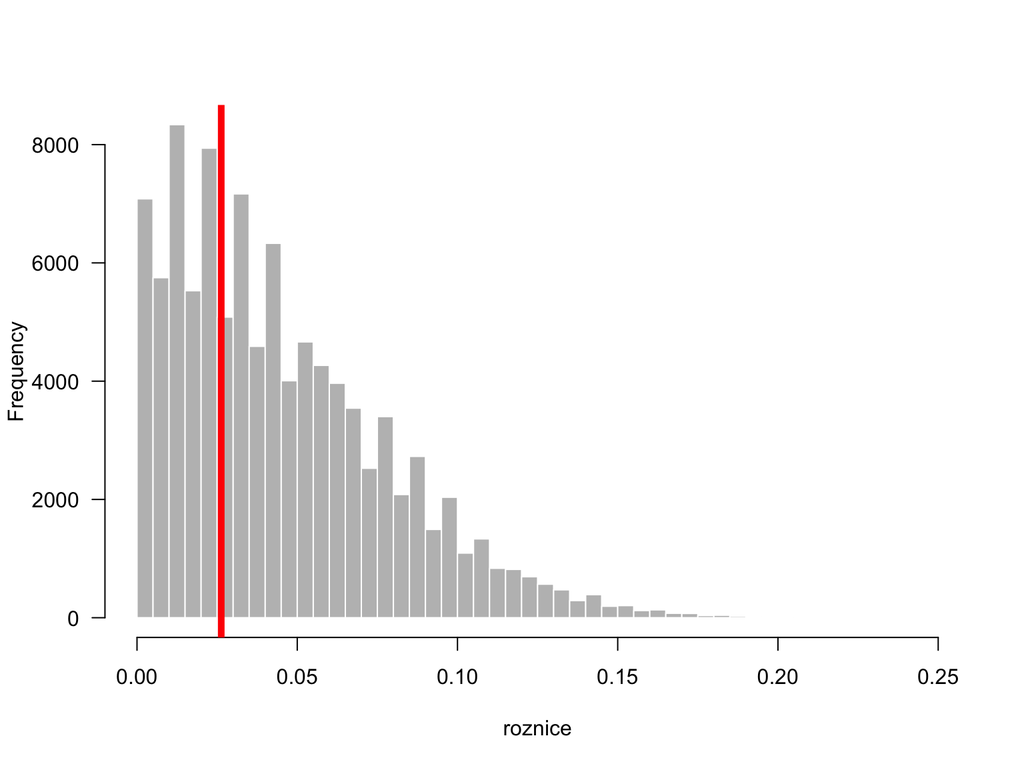

```r
hist(roznice, 50, col="grey", main="", las=1, border="white")
abline(v=obserwowana_roznica, col="red", lwd=5)
```

# Czy serial Friends jest lepszy niż serial Braking Bed?

Wykres pomaga w zrozumieniu tego rozkładu, ale aby podjąć decyzje lepiej mieć jedną liczbę. Policzmy jaka część różnic dla losowych fluktuacji jest większa niż obserwowana różnica.

```r
mean(roznice > obserwowana_roznica) + 1/100000
```

```
## [1] 0.64074
```

Czy wiedząc, że gdy próby są równe to w wyniku losowych fluktuacji w 64% przypadków obserwuje się większą różnicę niż ta pomiędzy *Friends* a *Breaking Bad* uznamy różnicę pomiędzy tymi dwoma serialami za istotną?

Pewnie nie. To jaki próg przyjmiemy zależy od konkretnego zastosowania, ale często za próg wybiera się 0.05.

# Czy serial Friends jest lepszy niż serial Sherlock?

# Czy serial Friends jest lepszy niż serial Sherlock?

```r
ocenyFriends     <- serialeIMDB[serialeIMDB$serial == "Friends", "ocena"]
ocenySherlock    <- serialeIMDB[serialeIMDB$serial == "Sherlock", "ocena"]
# moduł różnicy średnich
(obserwowana_roznica <- abs(mean(ocenyBreakingBad) - mean(ocenySherlock)))
```

```
## [1] 0.4872434
```

Powtórzmy test permutacyjny dla tych dwóch seriali. Tym razem obserwowana różnica jest wyższa niż praktycznie wszystkie wartości wygenerowane rpzez test permutacyjny.

```r
# permutacyjny test
liczbaFriends <- length(ocenyFriends)
roznice <- replicate(100000, {
  wymieszane <- sample(c(ocenyFriends, ocenySherlock))
  oceny1 <- wymieszane[1:liczbaFriends]
  oceny2 <- wymieszane[-(1:liczbaFriends)]
  # różnica pomiedzy losowymi grupami
  abs(mean(oceny1) - mean(oceny2))
})
mean(roznice > obserwowana_roznica) + 1/100000
```

```
## [1] 2e-05
```

# Które dwa seriale różnią się istotnie?

Używając poniższej aplikacji można porównać dowolne dwa seriale oraz ocenić, czy różnica jest statystycznie istotnie różna.

[interactive chart not shown]

# Zadania

- Znajdź dwa seriale (inne niż Friends i Sherlock), które różnią się istotnie, przyjmując za próg istotności 0.05.
- Znajdź dwa seriale (inne niż Friends i Breaking Bad), które nie różnią się istotnie, przyjmując za próg istotności 0.05.